# ENV 797 - Time Series Analysis for Energy and Environment Applications | Spring 2025

Assignment 7 - Due date 03/06/25

Ananya Aggarwal

## Directions

You should open the .rmd file corresponding to this assignment on RStudio. The file is available on our class repository on Github. And to do so you will need to fork our repository and link it to your RStudio.

Once you have the file open on your local machine the first thing you will do is rename the file such that it includes your first and last name (e.g., “LuanaLima_TSA_A07_Sp25.Rmd”). Then change “Student Name” on line 4 with your name.

Then you will start working through the assignment by **creating code and output** that answer each question. Be sure to use this assignment document. Your report should contain the answer to each question and any plots/tables you obtained (when applicable).

When you have completed the assignment, **Knit** the text and code into a single PDF file. Submit this pdf using Sakai.

Packages needed for this assignment: “forecast”,“tseries”. Do not forget to load them before running your script, since they are NOT default packages.\

## Set up

```r
#Load/install required package here
library(lubridate)
```

```r
library(ggplot2)
library(tseries)
library(forecast)
library(outliers)
library(Kendall)
library(cowplot)
library(tidyverse)
#setting the theme
mytheme <- theme_minimal(base_size = 10) +
  theme(plot.title = element_text(hjust = 0.5),
        legend.position = "bottom")
theme_set(mytheme)
```

## Importing and processing the data set

Consider the data from the file “Net_generation_United_States_all_sectors_monthly.csv”. The data corresponds to the monthly net generation from January 2001 to December 2020 by source and is provided by the US Energy Information and Administration. **You will work with the natural gas column only**.

### Q1

Import the csv file and create a time series object for natural gas. Make sure you specify the **start=** and **frequency=** arguments. Plot the time series over time, ACF and PACF.

```r
getwd()
```

```
## [1] "C:/Users/nancy/Desktop/Time Series Analysis/TSA_Sp25/Assignments"
```

```r
net_generation_all <- read.csv(file = "../Data/Net_generation_United_States_all_sectors_monthly.csv",
                               header = TRUE, skip = 4)
head(net_generation_all)
```

|  | Month | all.fuels..utility.scale..thousand.megawatthours | coal.thousand.megawatthours | natural.gas.thousand.megawatthours | nuclear.thousand.megawatthours | conventional.hydroelectric.thousand.megawatthours |
| --- | --- | --- | --- | --- | --- | --- |
| 1 | Dec 2020 | 344970.4 | 78700.33 | 125703.7 | 69870.98 | 23086.37 |
| 2 | Nov 2020 | 302701.8 | 61332.26 | 109037.2 | 61759.98 | 21831.88 |
| 3 | Oct 2020 | 313910.0 | 59894.57 | 131658.2 | 59362.46 | 18320.72 |
| 4 | Sep 2020 | 334270.1 | 68448.00 | 141452.7 | 65727.32 | 19161.97 |
| 5 | Aug 2020 | 399504.2 | 91252.48 | 173926.6 | 68982.19 | 24081.57 |
| 6 | Jul 2020 | 414242.5 | 89831.36 | 185444.8 | 69385.44 | 27675.94 |

```r
#the data is saved in a reverse order, starting with 2020
n_var <- ncol(net_generation_all) - 1
n_obs <- nrow(net_generation_all)

summary(net_generation_all)
```

```
##     Month           all.fuels..utility.scale..thousand.megawatthours
##  Length:240         Min.   :276127
##  Class :character   1st Qu.:309142
##  Mode  :character   Median :328297
##                     Mean   :336382
##                     3rd Qu.:357671
##                     Max.   :421797
##  coal.thousand.megawatthours natural.gas.thousand.megawatthours
##  Min.   : 40624              Min.   : 37967
##  1st Qu.:113769              1st Qu.: 62245
##  Median :141665              Median : 84415
##  Mean   :135391              Mean   : 88028
##  3rd Qu.:161751              3rd Qu.:108385
##  Max.   :190135              Max.   :185445
##  nuclear.thousand.megawatthours
##  Min.   :54547
##  1st Qu.:62651
##  Median :65775
##  Mean   :66037
##  3rd Qu.:70438
##  Max.   :74649
##  conventional.hydroelectric.thousand.megawatthours
##  Min.   :14743
##  1st Qu.:19568
##  Median :22307
##  Mean   :22639
##  3rd Qu.:25475
##  Max.   :32607
```

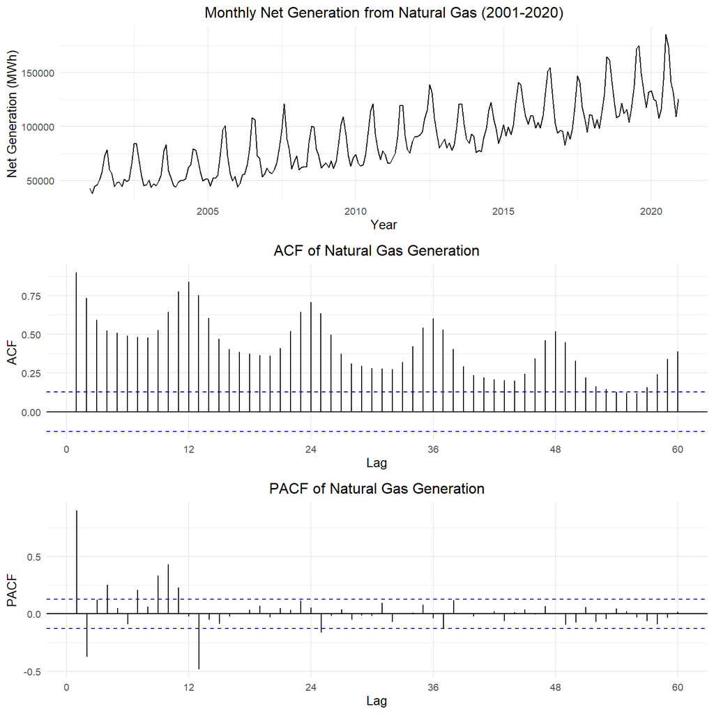

```r
#extracting the data for natural gas only
net_generation_gas <- net_generation_all %>%
  select(Month, natural.gas.thousand.megawatthours) %>%
  mutate(Month = my(Month)) %>%
  arrange(Month)

ts_netgen_gas <- ts(net_generation_gas[,2], start = c(2001,1), frequency = 12)

netgen_gas_plot <- autoplot(ts_netgen_gas) +
  ggtitle("Monthly Net Generation from Natural Gas (2001-2020)") +
  xlab("Year") + ylab("Net Generation (MWh)")

netgen_gas_ACF <- ggAcf(ts_netgen_gas, lag.max = 60) + ggtitle("ACF of Natural Gas Generation")
netgen_gas_PACF <- ggPacf(ts_netgen_gas, lag.max = 60) + ggtitle("PACF of Natural Gas Generation")

plot_grid(netgen_gas_plot, netgen_gas_ACF, netgen_gas_PACF, ncol=1)
```

### Q2

Using the $decompose()$ and the $seasadj()$ functions create a series without the seasonal component, i.e., a deseasonalized natural gas series. Plot the deseasonalized series over time and corresponding ACF and PACF. Compare with the plots obtained in Q1.

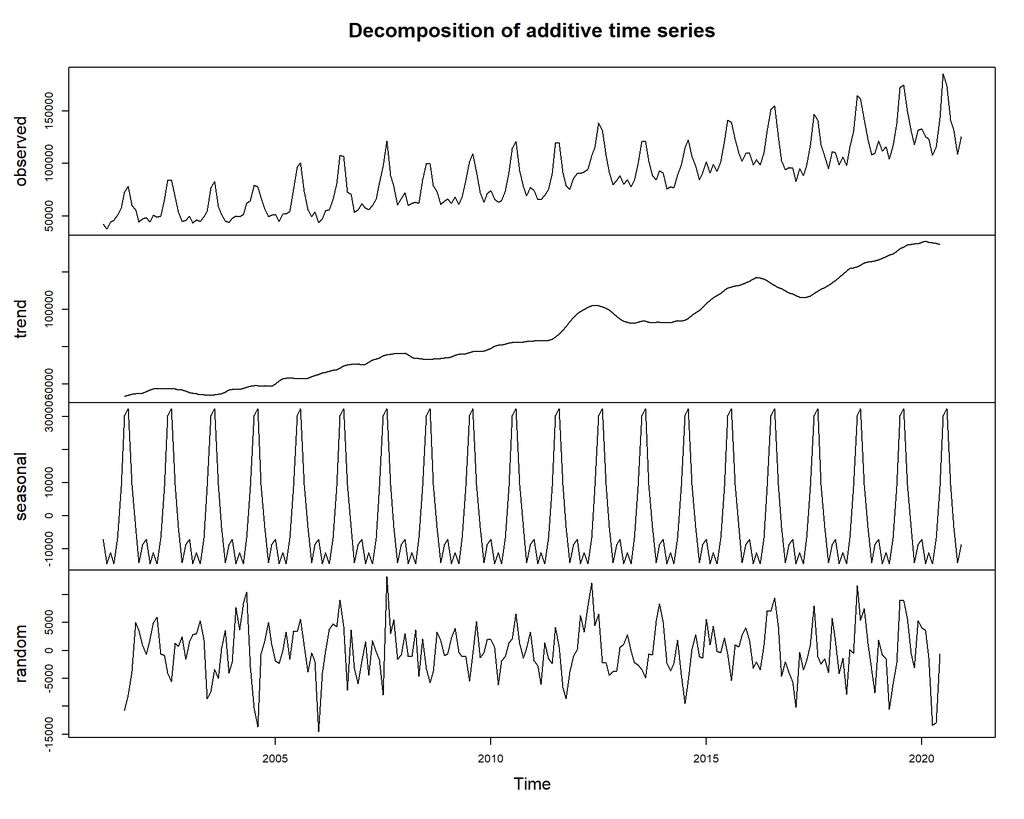

```r
decomp_netgen_gas <- decompose(ts_netgen_gas)
plot(decomp_netgen_gas)
```

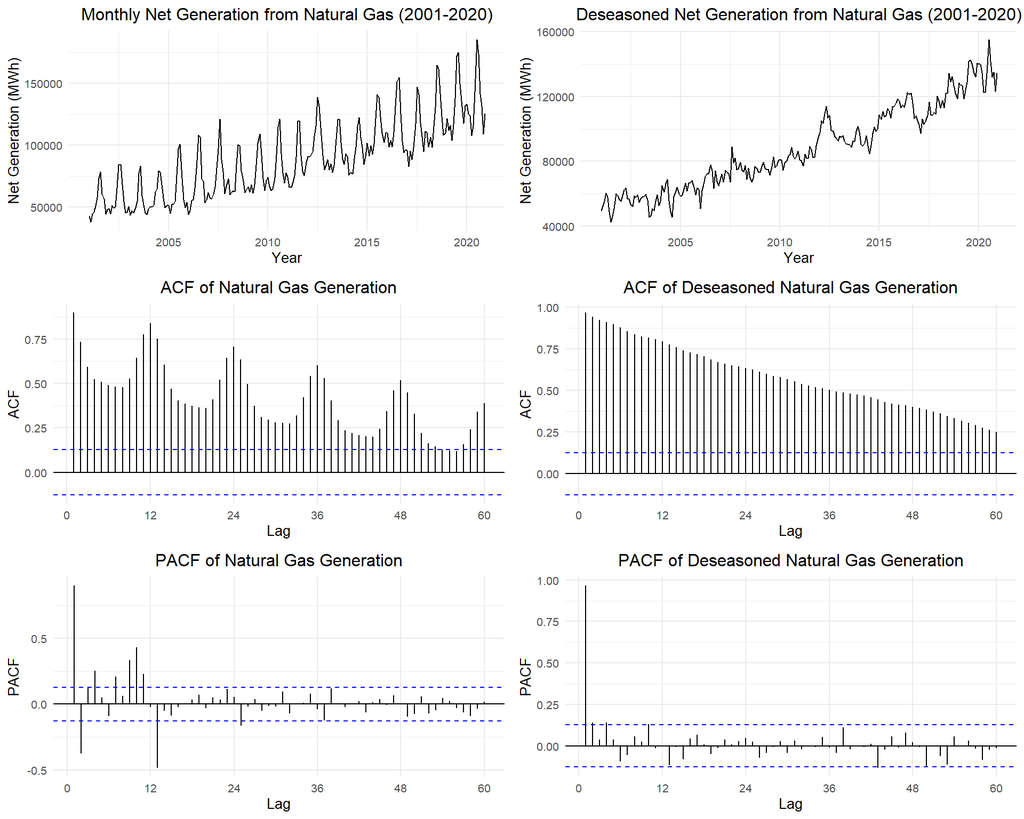

```r
deseas_netgen_gas <- seasadj(decomp_netgen_gas)
deseas_gas_plot <- autoplot(deseas_netgen_gas)+
  ggtitle("Deseasoned Net Generation from Natural Gas (2001-2020)") +
  xlab("Year") + ylab("Net Generation (MWh)")

deseas_gas_ACF <- ggAcf(deseas_netgen_gas, lag.max = 60) + ggtitle("ACF of Deseasoned Natural Gas Generation")
deseas_gas_PACF <- ggPacf(deseas_netgen_gas, lag.max = 60) + ggtitle("PACF of Deseasoned Natural Gas Generation")

plot_grid(netgen_gas_plot, deseas_gas_plot, netgen_gas_ACF, deseas_gas_ACF, netgen_gas_PACF, deseas_gas_PACF, ncol=2)
```

> Answer:

> Time Series - The original time series shows an increasing trend with a strong seasonal patterns. The deseasoned time series gets rid of these peaks and troughs, leaving only the underlying upward trend and random variations.

> ACF - The ACF of the original series is decaying over time, however, it has significant spikes at regular lags, reflecting the seasonal cycles. Thus, when the seasonal component is removed in the deseasoned series, the wave pattern disappears and we only see the decaying trend over time in ACF.

> PACF - The PACF of the original series shows a slight wave pattern in the first year (i.e. first 12 lags) with significant spikes at lag 1 and lag 13 representing the monthly seasonal patterns. The PACF of the deseasoned series has fewer significant spikes, except for at lag 1, suggesting that most of the seasonality has been removed.

## Modeling the seasonally adjusted or deseasonalized series

### Q3

Run the ADF test and Mann Kendall test on the deseasonalized data from Q2. Report and explain the results.

```r
print("ADF Test Summary")
```

```
## [1] "ADF Test Summary"
```

```r
print(adf.test(deseas_netgen_gas,alternative="stationary"))
```

```
##
##  Augmented Dickey-Fuller Test
##
## data:  deseas_netgen_gas
## Dickey-Fuller = -4.0271, Lag order = 6, p-value = 0.01
## alternative hypothesis: stationary
```

```r
print("Mann Kendall Test Summary")
```

```
## [1] "Mann Kendall Test Summary"
```

```r
print(MannKendall(deseas_netgen_gas))
```

```
## tau = 0.843, 2-sided pvalue =< 2.22e-16
```

> Answer: The p-value (=0.01) is lower than 0.05, which is why we reject the null hypothesis of non-stationarity. This means that the deseasoned time series is stationary, i.e., it does not have a unit root. The high positive value of 0.843 from the Mann Kendall test indicates a strong positive trend in the data, which we saw from the graph as well. And the extremely low p-value confirms the statistical significance of this trend. These two results indicate that while the mean changes over time due to the trend, the deviations from this trend are temporary, and the series returns to its long-run mean over time.

### Q4

Using the plots from Q2 and test results from Q3 identify the ARIMA model parameters $p,d$ and $q$. Note that in this case because you removed the seasonal component prior to identifying the model you don’t need to worry about seasonal component. Clearly state your criteria and any additional function in R you might use. DO NOT use the $auto.arima()$ function. You will be evaluated on ability to understand the ACF/PACF plots and interpret the test results.

```r
ndiffs(deseas_netgen_gas)
```

```
## [1] 1
```

```r
p <- 1
d <- ndiffs(deseas_netgen_gas)
q <- 0

cat("Estimated ARIMA order: ARIMA(", p, ",", d, ",", q, ")\n")
```

```
## Estimated ARIMA order: ARIMA( 1 , 1 , 0 )
```

### Q5

Use `Arima()` from package “forecast” to fit an ARIMA model to your series considering the order estimated in Q4. You should allow constants in the model, i.e., `include.mean = TRUE` or `include.drift=TRUE`. **Print the coefficients** in your report. Hint: use the `cat()` or `print()` function to print.

```r
arima_netgen_gas <- Arima(deseas_netgen_gas, order = c(p,d,q), include.mean = TRUE, include.drift = TRUE)
print(arima_netgen_gas)
```

```
## Series: deseas_netgen_gas
## ARIMA(1,1,0) with drift
##
## Coefficients:
##           ar1     drift
##       -0.1479  348.3927
## s.e.   0.0644  308.8385
##
## sigma^2 = 30254066:  log likelihood = -2396.54
## AIC=4799.07   AICc=4799.18   BIC=4809.5
```

### Q6

Now plot the residuals of the ARIMA fit from Q5 along with residuals ACF and PACF on the same window. You may use the $checkresiduals()$ function to automatically generate the three plots. Do the residual series look like a white noise series? Why?

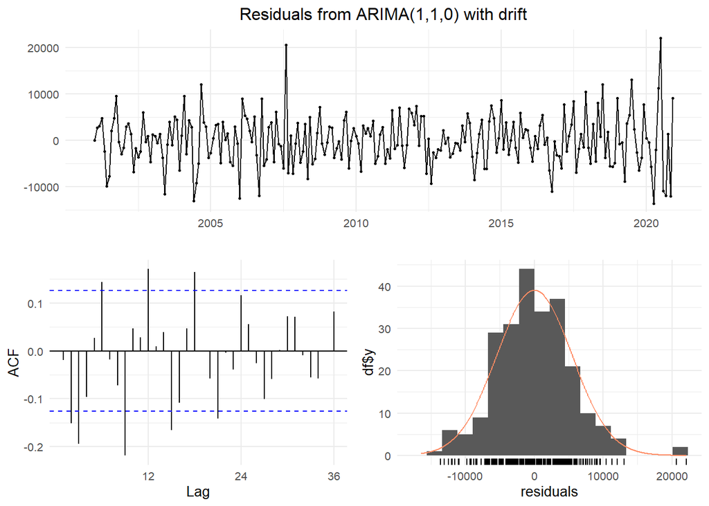

```
##
##  Ljung-Box test
##
## data:  Residuals from ARIMA(1,1,0) with drift
## Q* = 72.475, df = 23, p-value = 5.015e-07
##
## Model df: 1.   Total lags used: 24
```

```r
checkresiduals(arima_netgen_gas)
```

## Modeling the original series (with seasonality)

### Q7

Repeat Q3-Q6 for the original series (the complete series that has the seasonal component). Note that when you model the seasonal series, you need to specify the seasonal part of the ARIMA model as well, i.e., $P$, $D$ and $Q$.

```r
#conducting the tests
print("ADF Test Summary")
```

```
## [1] "ADF Test Summary"
```

```r
print(adf.test(ts_netgen_gas,alternative="stationary"))
```

```
##
##  Augmented Dickey-Fuller Test
##
## data:  ts_netgen_gas
## Dickey-Fuller = -8.9602, Lag order = 6, p-value = 0.01
## alternative hypothesis: stationary
```

```r
print("Mann Kendall Test Summary")
```

```
## [1] "Mann Kendall Test Summary"
```

```r
print(MannKendall(ts_netgen_gas))
```

```
## tau = 0.651, 2-sided pvalue =< 2.22e-16
```

```r
#confirming if the series needs to be differenced using ndsiffs
print("Number of times to difference")
```

```
## [1] "Number of times to difference"
```

```r
nsdiffs(ts_netgen_gas)
```

```
## [1] 1
```

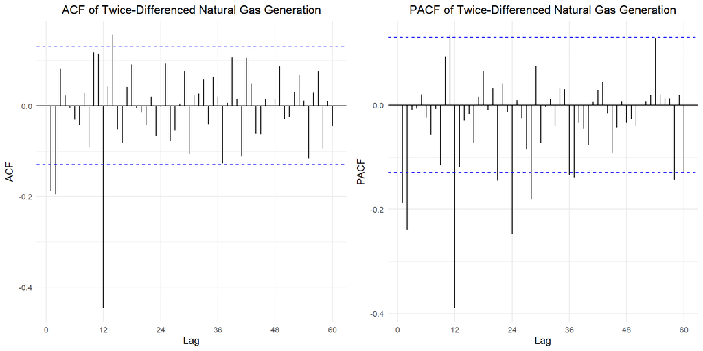

```r
#differencing the series for both trend and seasonality to check the ACF and PACF plots
diff_trend_netgen_gas <- diff(ts_netgen_gas,lag=1, differences=1)
diff_both_netgen_gas <- diff(diff_trend_netgen_gas, lag=12, differences=1)

diff_gas_ACF <- ggAcf(diff_both_netgen_gas, lag.max = 60) + ggtitle("ACF of Twice-Differenced Natural Gas Generation")
diff_gas_PACF <- ggPacf(diff_both_netgen_gas, lag.max = 60) + ggtitle("PACF of Twice-Differenced Natural Gas Generation")

plot_grid(diff_gas_ACF, diff_gas_PACF)
```

```r
#defining the model parameters and fitting in SARIMA model
p_orig <- 1
d_orig <- ndiffs(ts_netgen_gas) #we difference for both trend and seasonality
q_orig <- 0
P <- 0
D <- nsdiffs(ts_netgen_gas)
Q <- 1
s <- 12 # monthly seasonality

sarima_netgen_gas <- Arima(ts_netgen_gas, order = c(p_orig, d_orig, q_orig),
                           seasonal = c(P,Q,D), include.mean = TRUE, include.drift = TRUE)
print(sarima_netgen_gas)
```

```
## Series: ts_netgen_gas
## ARIMA(1,1,0)(0,1,1)[12]
##
## Coefficients:
##           ar1     sma1
##       -0.1808  -0.6898
## s.e.   0.0655   0.0557
##
## sigma^2 = 30626308:  log likelihood = -2281.43
## AIC=4568.86   AICc=4568.96   BIC=4579.13
```

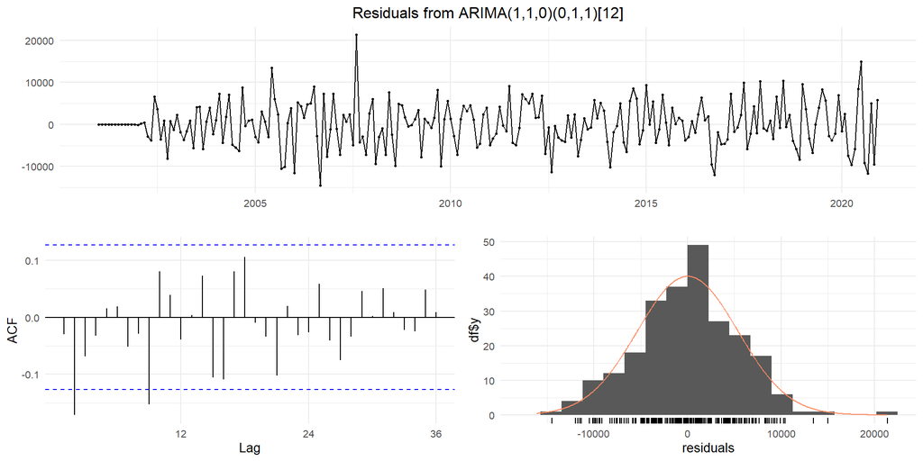

```
##
##  Ljung-Box test
##
## data:  Residuals from ARIMA(1,1,0)(0,1,1)[12]
## Q* = 33.681, df = 22, p-value = 0.05291
##
## Model df: 2.   Total lags used: 24
```

```r
checkresiduals(sarima_netgen_gas)
```

> Answer: The residuals series looks random, i.e., showing no clear patterns as they fluctuate around zero. There appear to be some outliers with some spikes reaching 20000, however fewer than we saw with the ARIMA model. The ACF of the residuals falls within the confidence bounds for almost the entire time period, indicating that the residual autocorrelations are insignificant.

### Q8

Compare the residual series for Q7 and Q6. Can you tell which ARIMA model is better representing the Natural Gas Series? Is that a fair comparison? Explain your response.

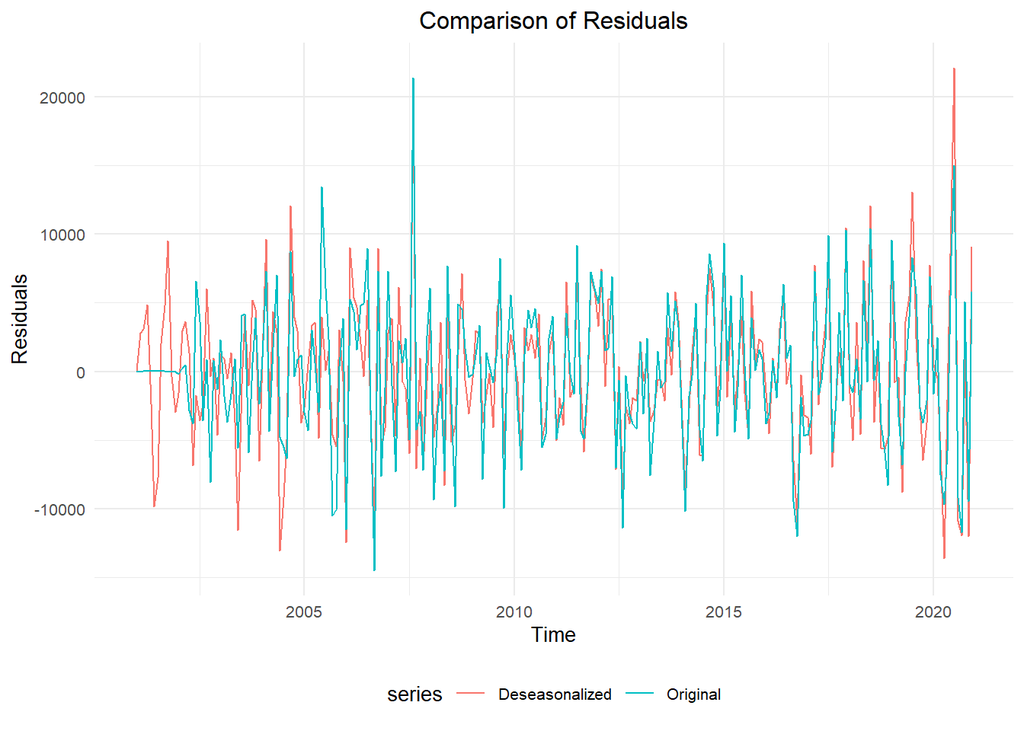

```r
autoplot(residuals(arima_netgen_gas), series = "Deseasonalized") +
  autolayer(residuals(sarima_netgen_gas), series = "Original") +
  ggtitle("Comparison of Residuals") +
  xlab("Time") + ylab("Residuals") +
  theme(legend.position = "bottom")
```

## Checking your model with the auto.arima()

**Please** do not change your answers for Q4 and Q7 after you ran the $auto.arima()$. It is **ok** if you didn’t get all orders correctly. You will not loose points for not having the same order as the $auto.arima()$.

### Q9

Use the $auto.arima()$ command on the **deseasonalized series** to let R choose the model parameter for you. What’s the order of the best ARIMA model? Does it match what you specified in Q4?

```r
auto_arima_deseas_gas <- auto.arima(deseas_netgen_gas)
print(auto_arima_deseas_gas)
```

```
## Series: deseas_netgen_gas
## ARIMA(1,1,1) with drift
##
## Coefficients:
##          ar1      ma1     drift
##       0.7065  -0.9795  359.5052
## s.e.  0.0633   0.0326   29.5277
##
## sigma^2 = 26980609:  log likelihood = -2383.11
## AIC=4774.21   AICc=4774.38   BIC=4788.12
```

> Answer: The autoregressive order of the best ARIMA model determined by the function, which matches what I concluded in Q4. However, it also indicates a moving average order of 1.

### Q10

Use the $auto.arima()$ command on the **original series** to let R choose the model parameters for you. Does it match what you specified in Q7?

```r
auto_arima_orig_gas <- auto.arima(ts_netgen_gas)
print(auto_arima_orig_gas)
```

```
## Series: ts_netgen_gas
## ARIMA(1,0,0)(0,1,1)[12] with drift
##
## Coefficients:
##          ar1     sma1     drift
##       0.7416  -0.7026  358.7988
## s.e.  0.0442   0.0557   37.5875
##
## sigma^2 = 27569124:  log likelihood = -2279.54
## AIC=4567.08   AICc=4567.26   BIC=4580.8
```

> Answer: The key difference is that the auto.arima function did not apply the regular difference (d=0), whereas I assumed that differencing based on the ndiffs output. The summary from the auto.arima function also includes the drift term that accounts for a deterministic trend in the data, which I happened to remove using d=1.